# Coronavirus v Čechách

## Přehled

Základní přehled (testy)

| Datum | Přírustkový počet testů | Kumulativní počet testů | Pozitivita testů (v %) |
| --- | --- | --- | --- |
| 2020-10-31 | 35920 | 2331249 | 31.82 |
| 2020-11-01 | 20414 | 2351663 | 32.09 |
| 2020-11-02 | 32498 | 2384161 | 28.43 |
| 2020-11-03 | 43010 | 2427171 | 28.11 |
| 2020-11-04 | 45122 | 2472293 | 34.85 |

Základní přehled (nákaza)

| Datum | Přírustkový počet nakažených | Kumulativní počet nakažených | Kumulativní počet vyléčených | Kumulativní počet úmrtí |
| --- | --- | --- | --- | --- |
| 2020-10-31 | 11428 | 335108 | 198978 | 3412 |
| 2020-11-01 | 6551 | 341659 | 199367 | 3603 |
| 2020-11-02 | 9240 | 350899 | 199955 | 3801 |
| 2020-11-03 | 12088 | 362987 | 200206 | 4036 |
| 2020-11-04 | 15727 | 378714 | 200343 | 4224 |

Aktuálně hospitalizovaní: `8236`

Podíl nakažených s těžkým průběhem: `4.56`%

Smrtnost: `1.12`%

# SIR MODELY

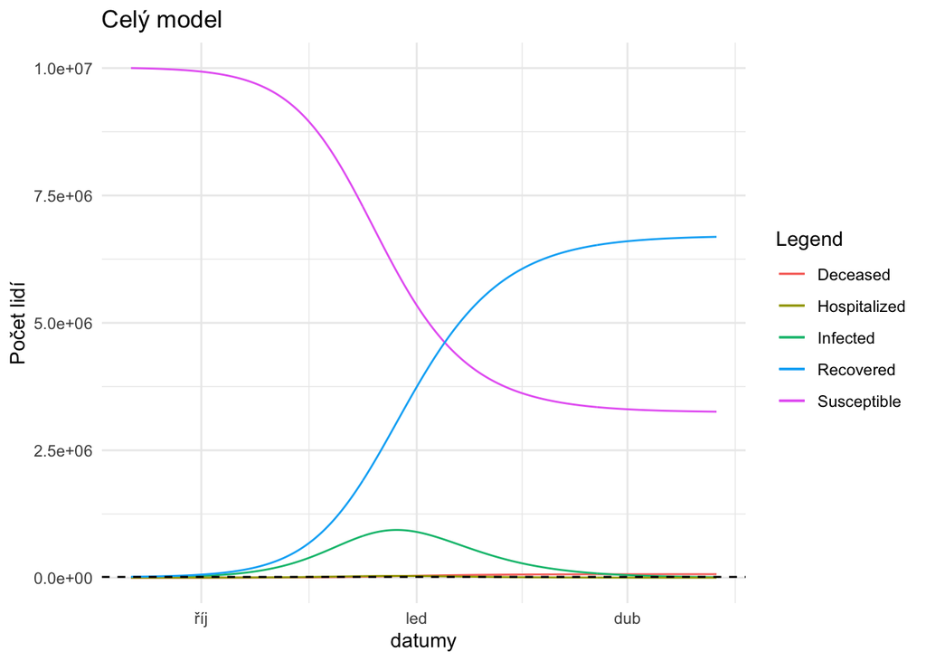

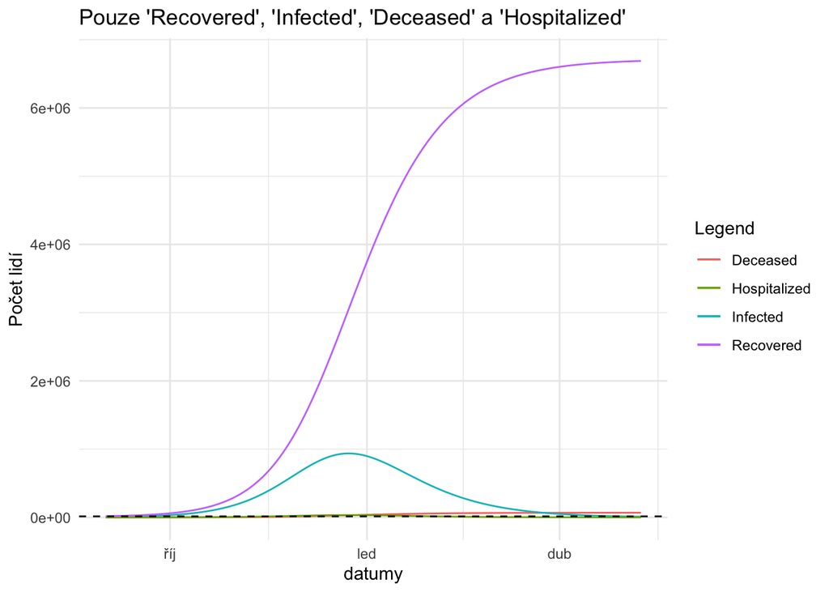

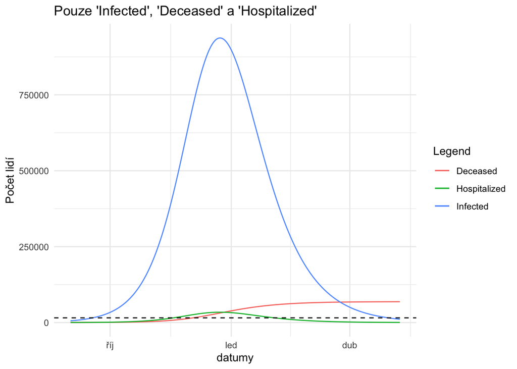

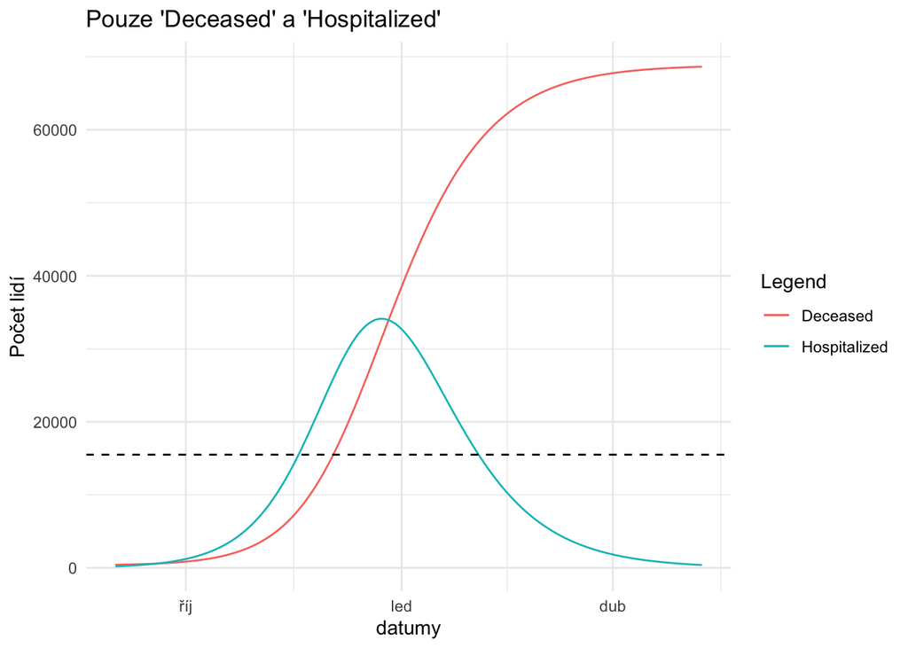

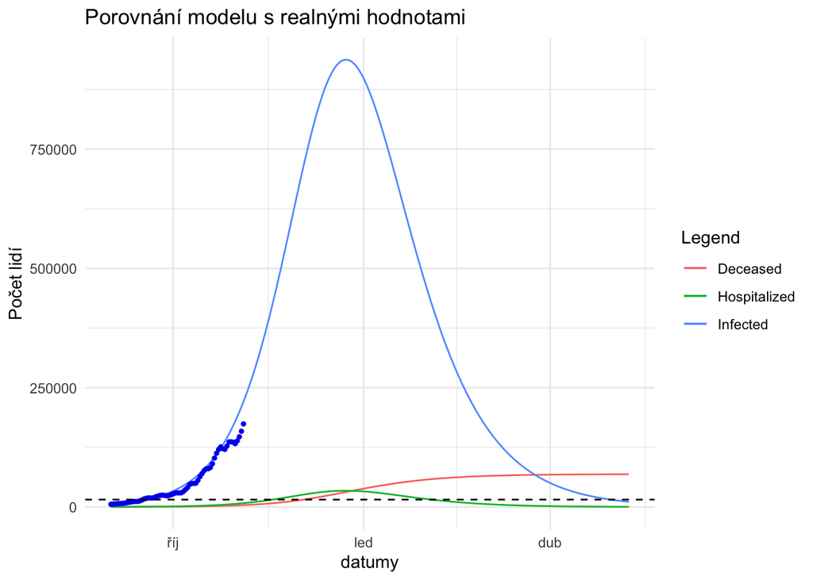

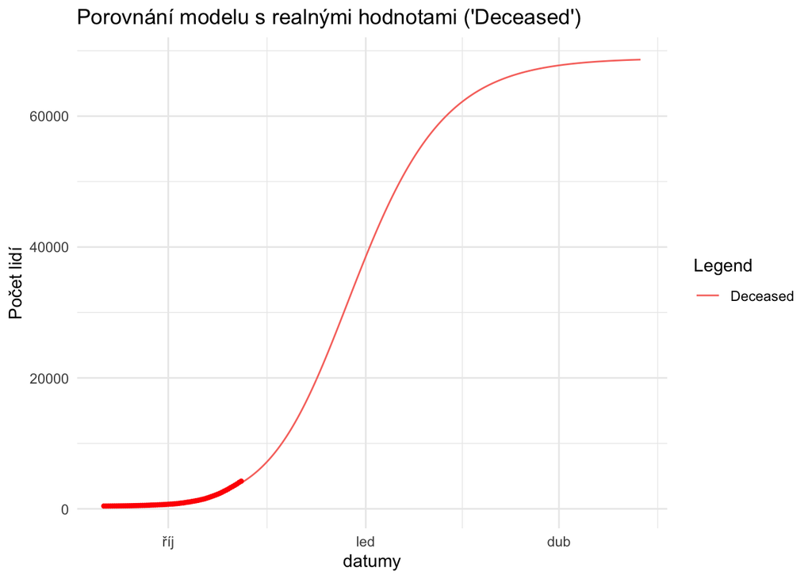

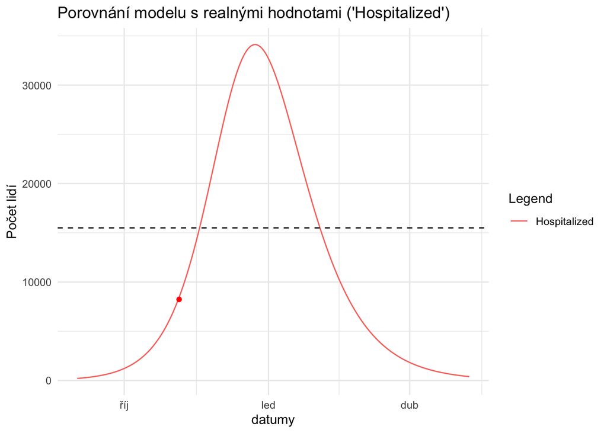

## Informace

`Peak nastane dne 2020-12-23 s počtem nakažených rovnu 937231 a aktuálním počtem hospitalizovných v nemocnicích 34115 lidí.`

`Kapacita nemocnic, která je stanovena na 15500 lůžek, bude při momentálním trendu překročena dne 2020-11-19`

`Celkově Covid-19 prodělá 6688258`

`Počet umrtí se zastaví na čísle 68637`

`Momentální hodnota rho je 1.682`

# Základní statistiky

## Testy

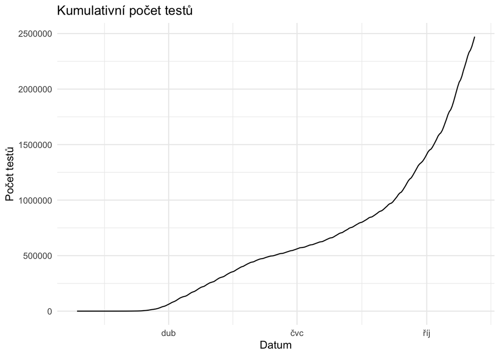

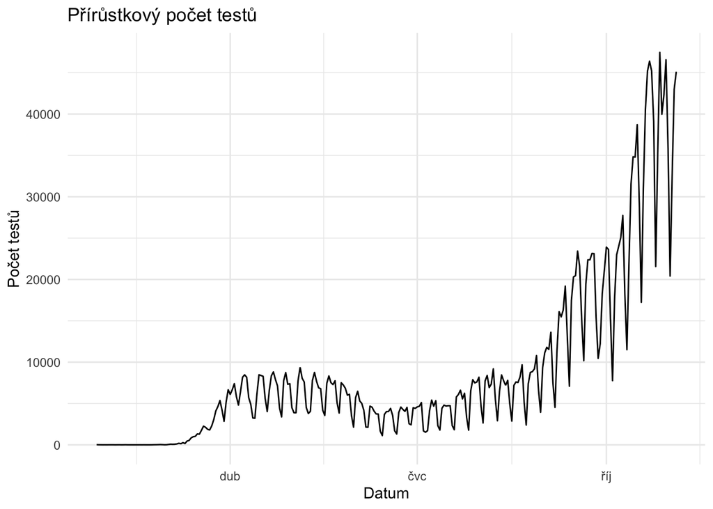

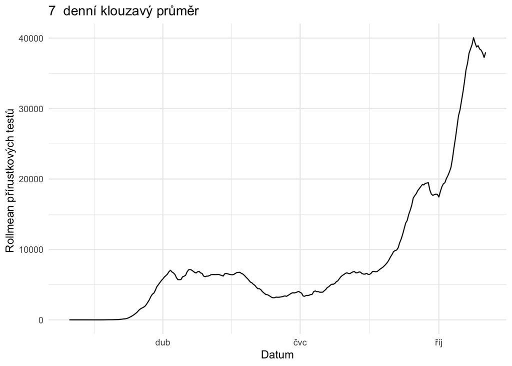

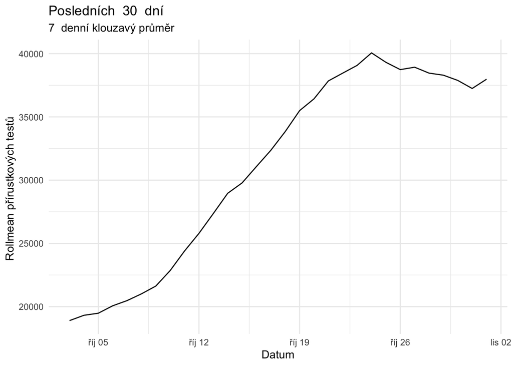

## Pozitivní případy

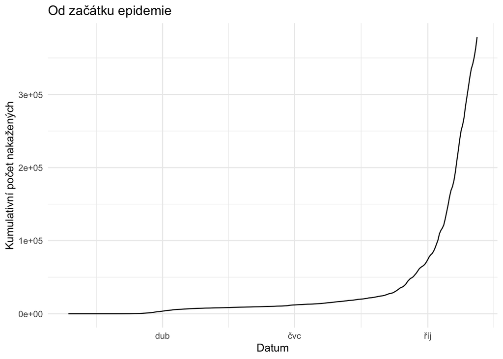

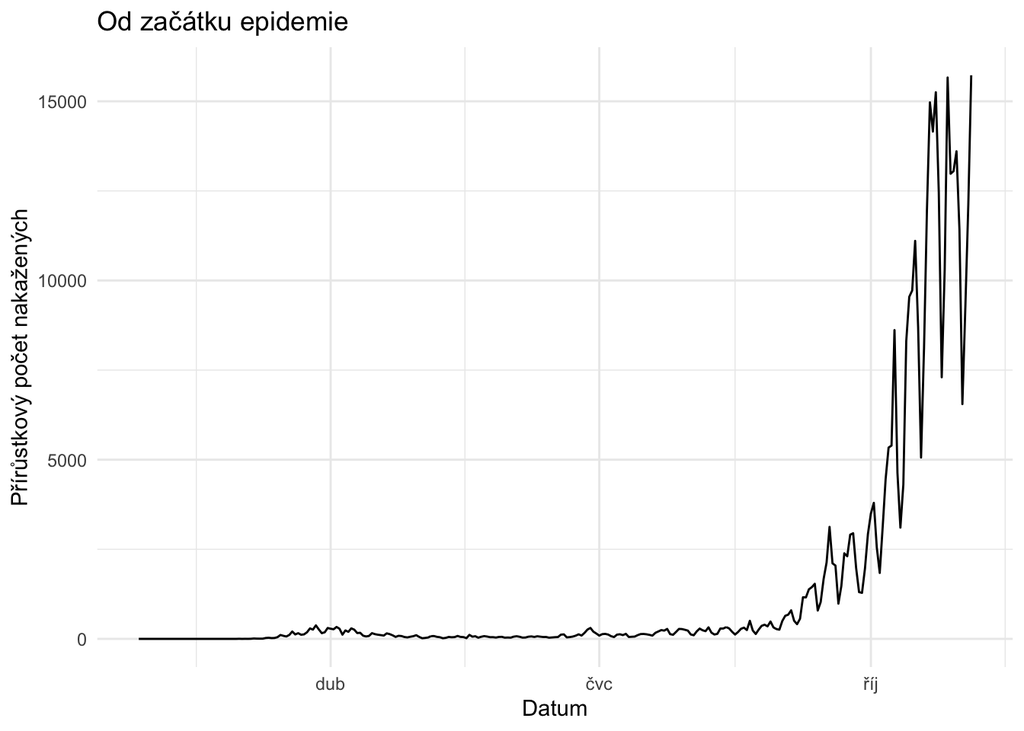

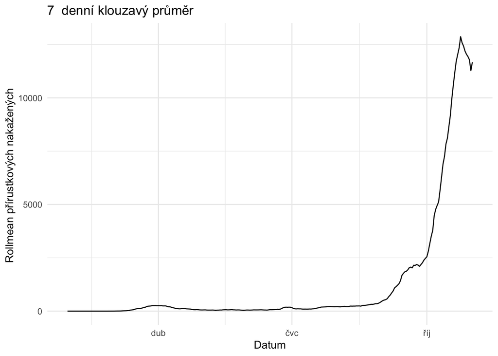

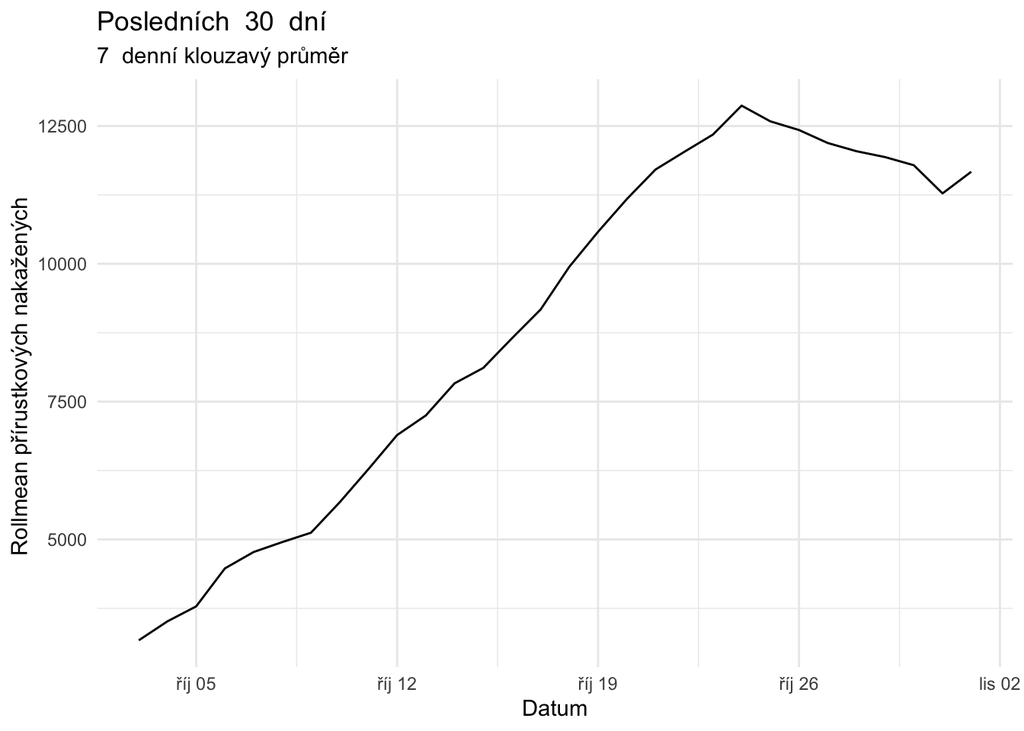

## Podíl pozitivních testů

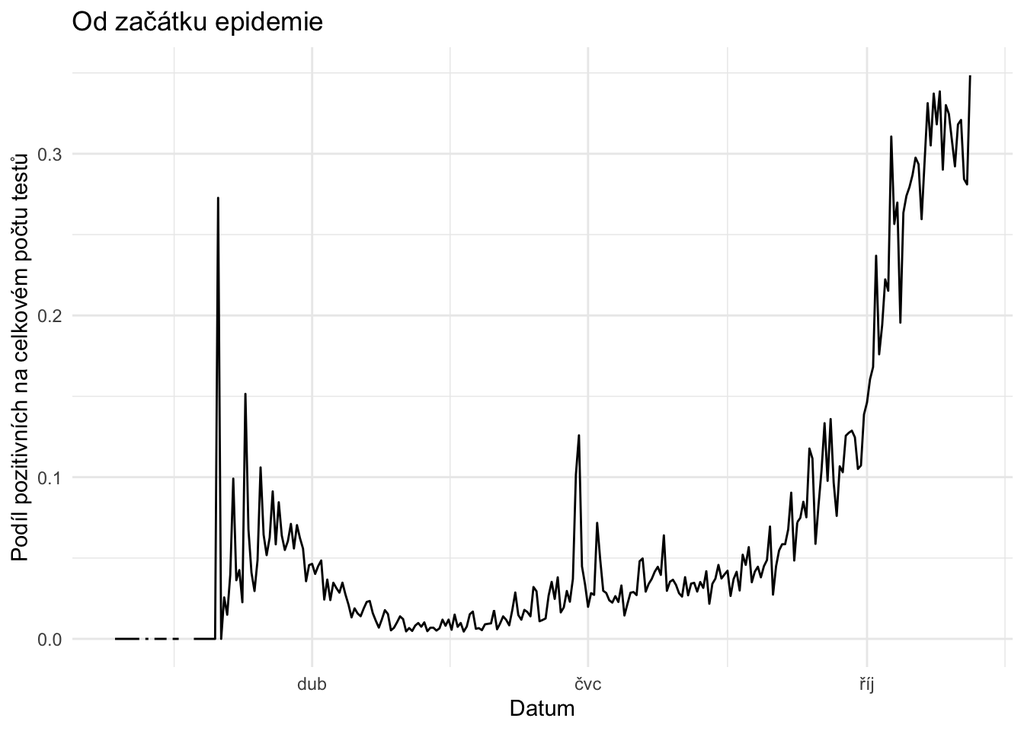

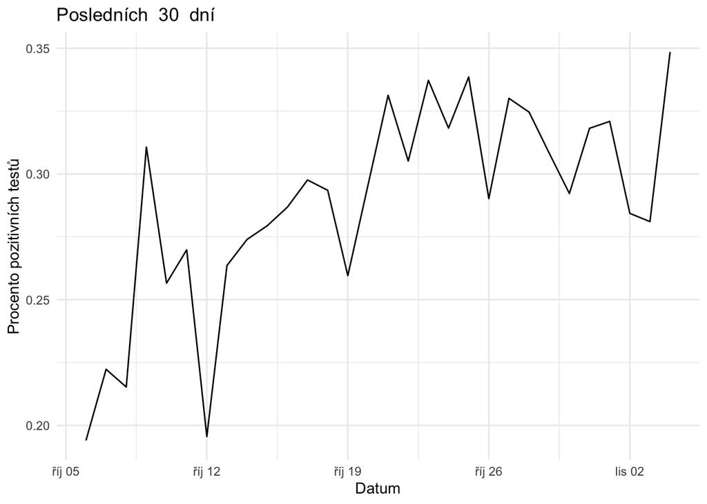

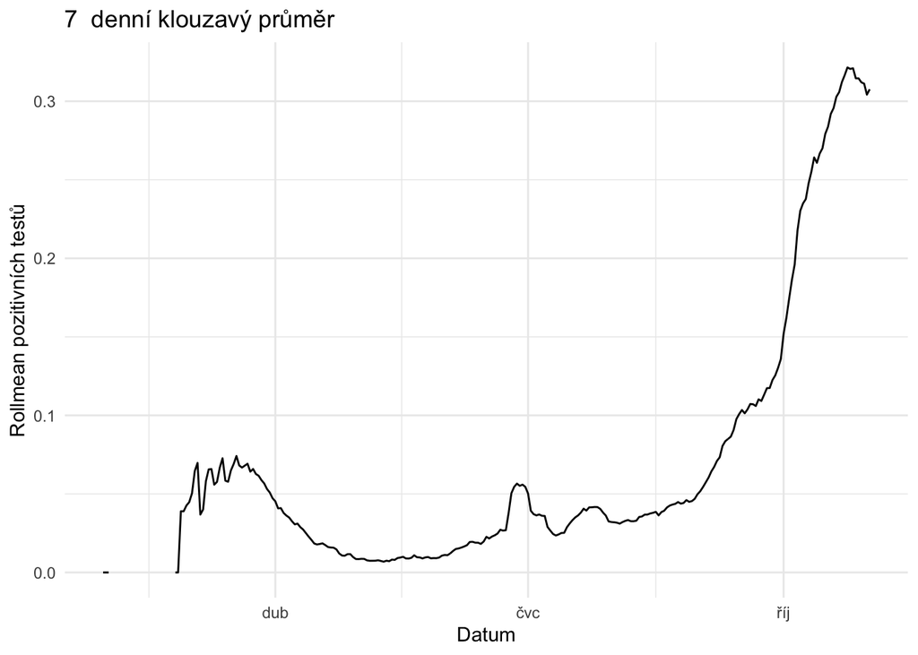

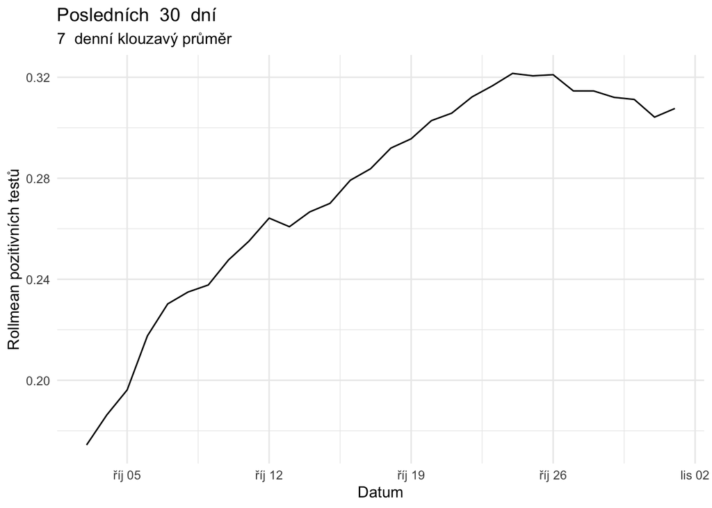

Podíl pozitivních testů na celkovém počtu od začátku epidemie je `15.318` %.

Podíl pozitivních testů na celkovém počtu za posledních 30 dní je `29.438` %.

# Modely

## Linearní model

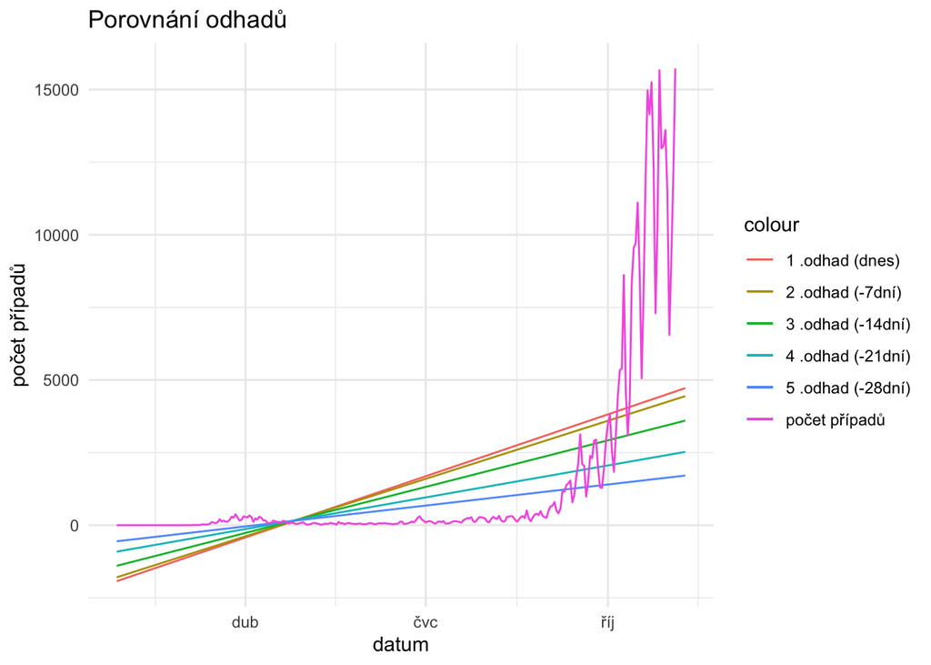

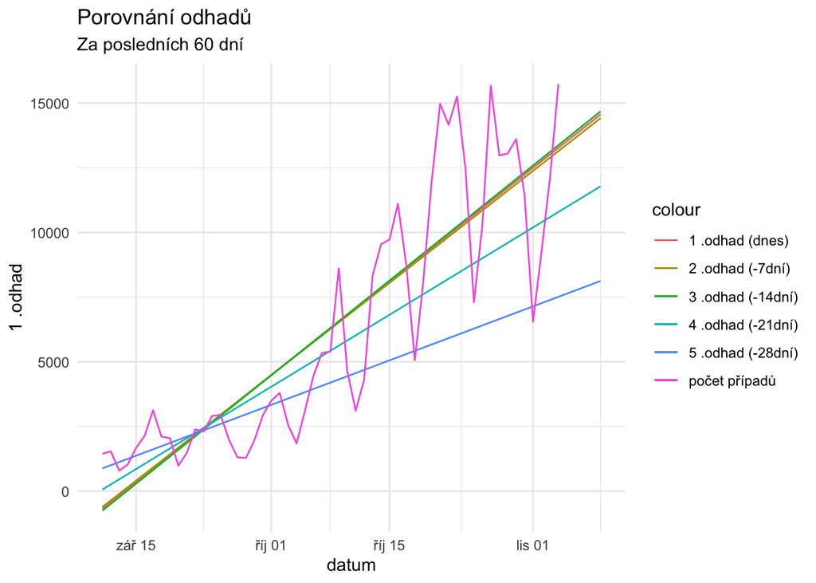

### Data (Lineární model)

#### Od začátku epidemie

Podle lineárního modelu bychom tímto tempem měli dne `2020-11-09` podle

- 1. odhadu `4720` nakažených denně
- 2. odhadu `4444` nakažených denně
- 3. odhadu `3601` nakažených denně
- 4. odhadu `2525` nakažených denně
- 5. odhadu `1709` nakažených denně

#### Za posledních `60` dní

Podle lineárního modelu bychom tímto tempem měli dne `2020-11-09` podle

- 1. odhadu `14561` nakažených denně
- 2. odhadu `14415` nakažených denně
- 3. odhadu `14677` nakažených denně
- 4. odhadu `11781` nakažených denně
- 5. odhadu `8123` nakažených denně

## Kvadratický model

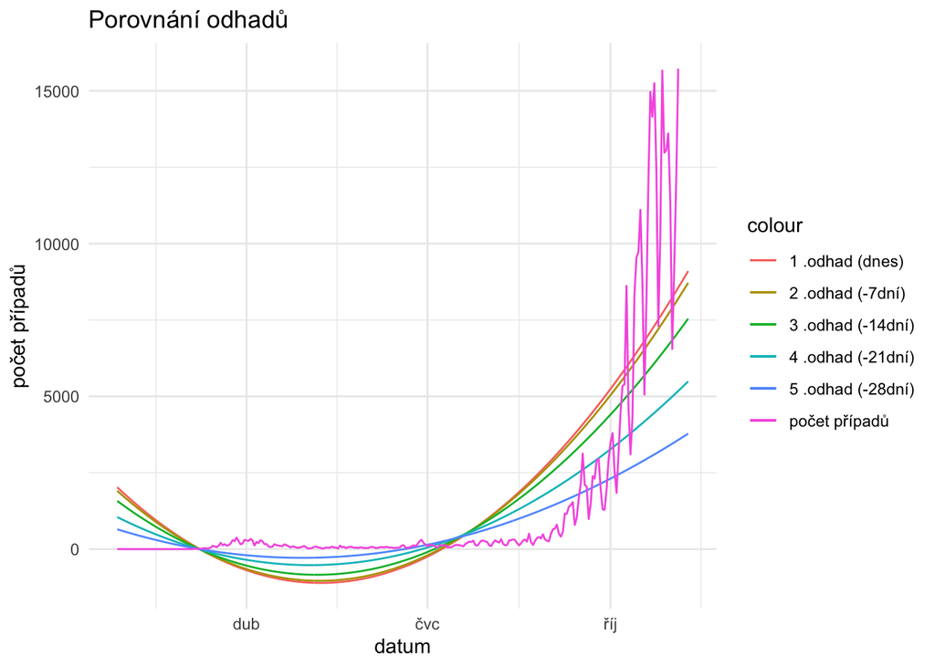

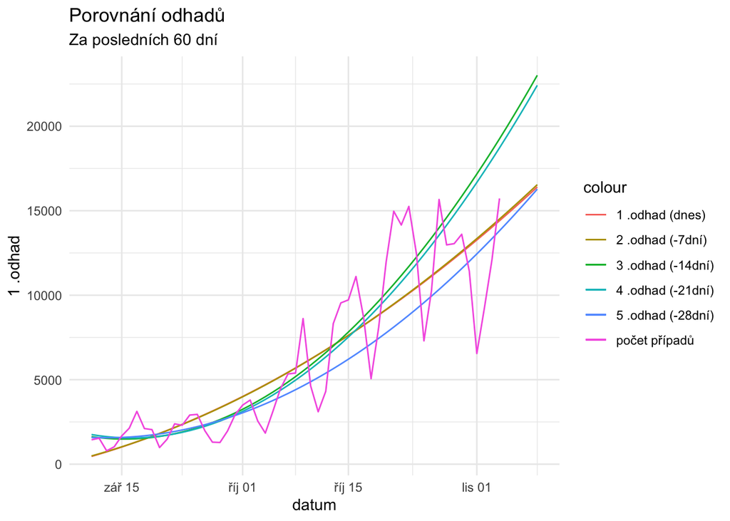

### Data (Kvadratický model)

#### Od začátku epidemie

Podle kvadratického modelu bychom tímto tempem měli dne `2020-11-09` podle

- 1. odhadu `9102` nakažených denně
- 2. odhadu `8717` nakažených denně
- 3. odhadu `7543` nakažených denně
- 4. odhadu `5489` nakažených denně
- 5. odhadu `3780` nakažených denně

#### Za posledních `60` dní

- 1. odhadu `16404` nakažených denně
- 2. odhadu `16542` nakažených denně
- 3. odhadu `23015` nakažených denně
- 4. odhadu `22422` nakažených denně
- 5. odhadu `16279` nakažených denně

## Exponential model

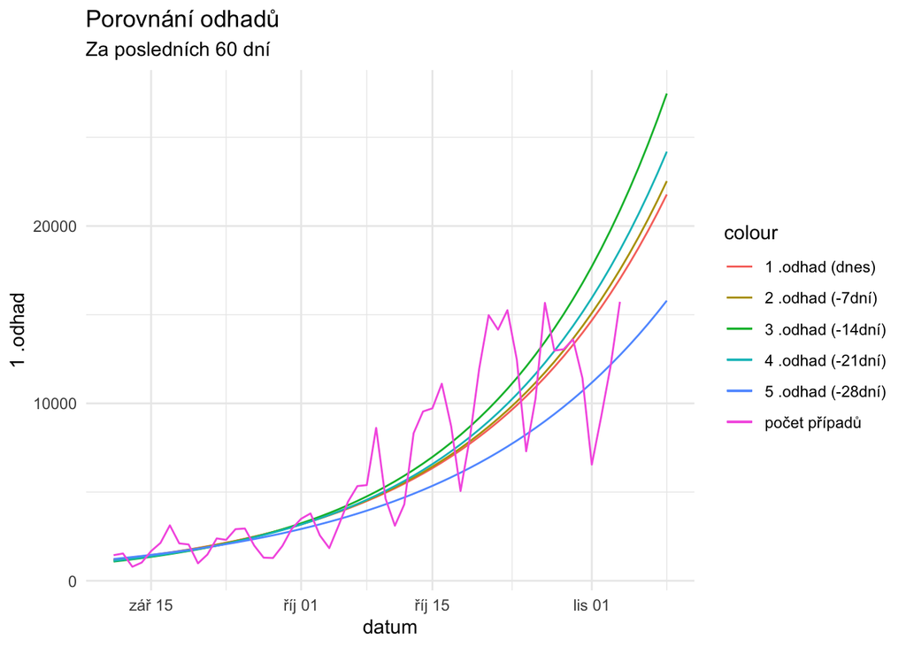

### Data (Exponential model)

#### Za posledních `60` dní

Podle exponencionálního modelu bychom tímto tempem měli dne `2020-11-09` podle

- 1. odhadu `21779` nakažených denně
- 2. odhadu `22531` nakažených denně
- 3. odhadu `27470` nakažených denně
- 4. odhadu `24192` nakažených denně
- 5. odhadu `15792` nakažených denně

Podle exponencionálního modelu bychom tímto tempem měli dnes dne `2020-11-05` podle

- 1. odhadu `17880` nakažených denně
- 2. odhadu `18437` nakažených denně
- 3. odhadu `22062` nakažených denně
- 4. odhadu `19641` nakažených denně
- 5. odhadu `13281` nakažených denně

# Informace

Update proběhl `2020-11-05 23:28:40`.

Poslední data jsou z `2020-11-04` ze stránek ministerstva zdravotnictví ČR (https://onemocneni-aktualne.mzcr.cz/covid-19)